# BIOS640-Week3-UNAssignment-DataVisualization

Chloé Langevin

2026-09-24

# Inital Setup

```r
# Loading necessary packages
library(pacman)
pacman::p_load(tidyverse)
pacman::p_load(here)
pacman::p_load(rio)
pacman::p_load(knitr)
pacman::p_load(cowplot)
pacman::p_load(ggpubr)
pacman::p_load(dplyr)
pacman::p_load(DT)
pacman::p_load(RColorBrewer)

# Importing data
nhanes_data <- import(here("Data", "cleaned_NHANES.csv"))
diet_data <- import(here("Data", "diet.csv"))

# Initial review of the data
dim(nhanes_data)
str(nhanes_data)
View(nhanes_data)
head(nhanes_data)
```

# 1. Reproducing and Arranging a Ggplot2 Figure

The gender distribution of patients across age groups and ethnicities was illustrated using two figures created with various ggplot2 tools. The figures were then combined using two different methods. The first method used the plot_grid() function from the cowplot package, while the second ued the ggarrange() function from the ggpubr package which provides an easy way to creat a shared legend. Although the overall layout is relatively simple, the combined figure with a shared legend provides a clearer and more cohesive presentation of the results.

## Individual Figures

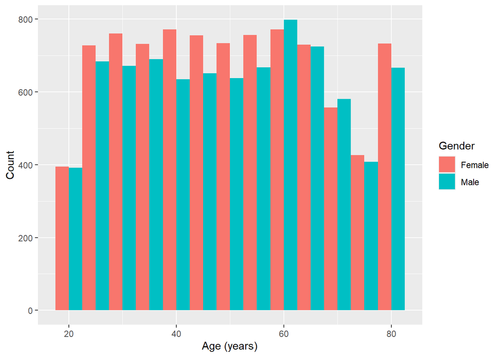

```r
# Gender distribution
p1 <- ggplot(
  nhanes_data %>% filter(age >= 20, age <= 80),
  aes(x = age, fill = gender)
) +
  geom_histogram(bins = 13, position = "dodge") +
  scale_x_continuous(breaks = seq(20, 80, by = 20)) +
  labs(
    x    = "Age (years)",
    y    = "Count",
    fill = "Gender"
  ) +
  theme_gray()
p1
```

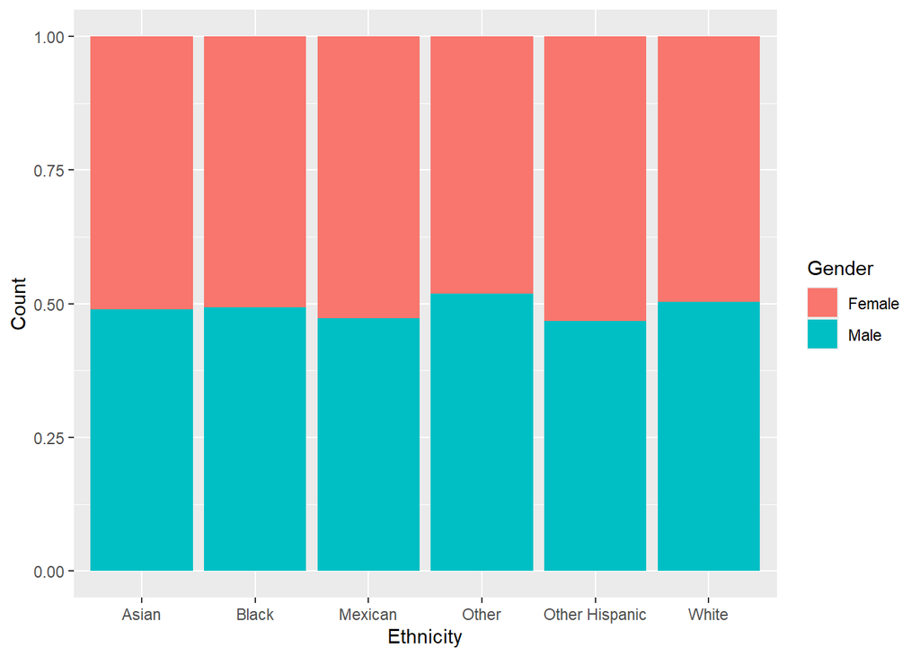

```r
# Ethnicity distribution
p2 <- ggplot(
  nhanes_data, aes(x = ethnicity_2, fill = gender)
) +
  geom_bar(position = "fill") +
  labs(
    x    = "Ethnicity",
    y    = "Count",
    fill = "Gender") +
  theme_gray()
p2
```

## Combined Figures

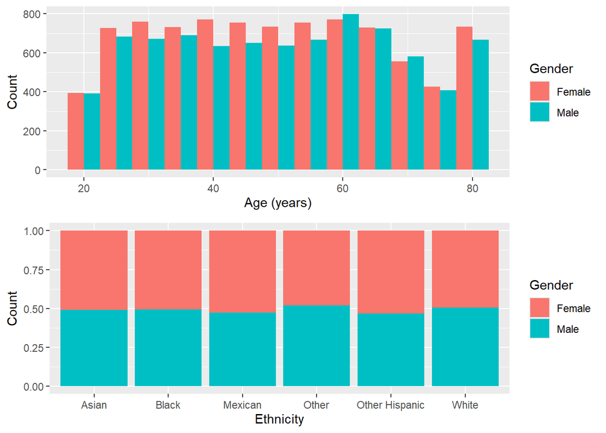

```r
# Combining plots
# Using cowplot()
cowplot_combined_figure <- plot_grid(
  p1,
  p2,
  nrow = 2
)

cowplot_combined_figure
```

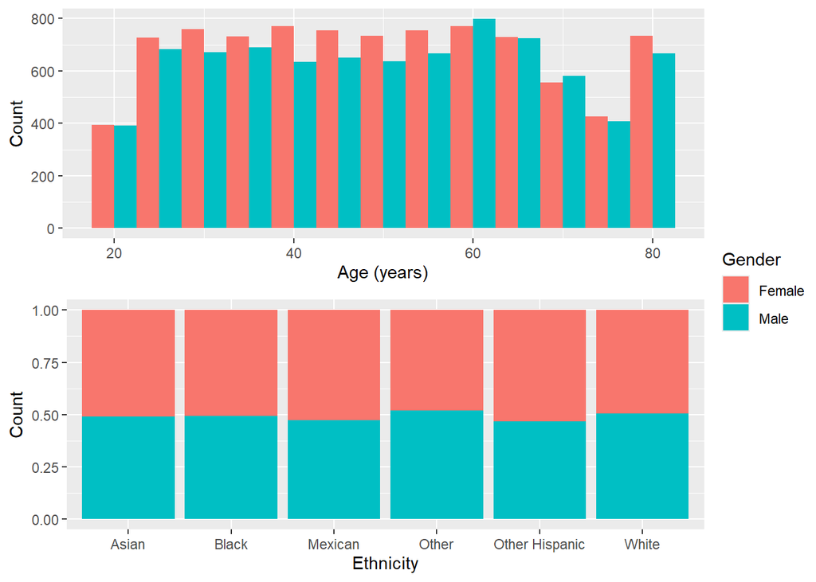

```r
# Using ggpubr()
ggpubr_combined_figure <- ggarrange(p1, p2, nrow = 2,
  common.legend = TRUE, legend = "right")

ggpubr_combined_figure
```

# 2. Visualizing Key Demographic Characteristics

The absence of missing values for the age, gender and both ethnicity variables was confirmed using summerize().

```r
# Adding an interactive table of the dataset
datatable(
  nhanes_data,
  # enable horizontal scrolling
  options = list(scrollX = TRUE)
)
```

|  | V1 | patient_id | bp_comment | systolic_bp_1 | diastolic_bp_1 | systolic_bp_2 | diastolic_bp_2 | systolic_bp_3 | diastolic_bp_3 | systolic_bp_4 | diastolic_bp_4 | wave_id | gender | age | ethnicity_1 | ethnicity_2 | education | marital_status | family_size | family_income | age_cat |
| --- | --- | --- | --- | --- | --- | --- | --- | --- | --- | --- | --- | --- | --- | --- | --- | --- | --- | --- | --- | --- | --- |
| 1 | 1 | 73557 |  | 122 | 72 | 114 | 76 | 102 | 74 |  |  | 2015 | Male | 69 | Black | Black | High School | Separated | 3 | $15,000 - $19,999 | 60+ |
| 2 | 2 | 73558 |  | 156 | 62 | 160 | 80 | 156 | 42 |  |  | 2015 | Male | 54 | White | White | High School | Married | 4 | $35,000 - $44,999 | 40-59 |
| 3 | 3 | 73559 |  | 140 | 90 | 140 | 76 | 146 | 80 |  |  | 2015 | Male | 72 | White | White | Some college | Married | 2 | $65,000 - $74,999 | 60+ |
| 4 | 4 | 73560 |  | 108 | 38 | 102 | 34 | 104 | 38 |  |  | 2015 | Male | 9 | White | White |  |  | 4 | $55,000 - $64,999 | 0-17 |
| 5 | 5 | 73561 |  | 136 | 86 | 134 | 88 | 142 | 86 |  |  | 2015 | Female | 73 | White | White | College graduate | Married | 2 | $100,000 or more | 60+ |
| 6 | 6 | 73562 |  | 160 | 84 | 158 | 82 | 154 | 80 |  |  | 2015 | Male | 56 | Mexican | Mexican | Some college | Divorced | 1 | $55,000 - $64,999 | 40-59 |
| 7 | 7 | 73563 |  |  |  |  |  |  |  |  |  | 2015 | Male | 0 | White | White |  |  | 3 | $100,000 or more | 0-17 |
| 8 | 8 | 73564 |  | 118 | 80 | 124 | 80 | 126 | 82 |  |  | 2015 | Female | 61 | White | White | College graduate | Widowed | 1 | $65,000 - $74,999 | 60+ |
| 9 | 9 | 73566 |  | 128 | 74 | 124 | 72 | 114 | 72 |  |  | 2015 | Female | 56 | White | White | High School | Divorced | 7 or more | $15,000 - $19,999 | 40-59 |
| 10 | 10 | 73567 |  | 140 | 78 | 142 | 78 | 142 | 76 |  |  | 2015 | Male | 65 | White | White | 9-11th grade | Widowed | 1 | $10,000 - $14,999 | 60+ |

[output cut: 29390 more lines]

```r
# Verifiying the number of missing values
nhanes_data %>%
  summarise(
    age         = sum(is.na(age)),
    gender      = sum(is.na(gender)),
    ethnicity_1 = sum(is.na(ethnicity_1)),
    ethnicity_2 = sum(is.na(ethnicity_2))
  )
```

```
##   age gender ethnicity_1 ethnicity_2
## 1   0      0           0           0
```

The age distribution shows a higher number of participants under 20 years old, followed by a relatively even distribution among participants between 20 and 60 years old. The number of participants then decreases after age 60, with a last spike at 80 years old which can be explain by the fact that every patient older than that was entered in the 80 years old category. .

The gender distribution is relatively balanced, with slightly more female than male participants.

For both ethnicity variables, Non-Hispanic White participants represent the largest group, followed by non-Hispanic Black participants and Mexican American participants. In the first ethnicity variable (RIDRETH1), the remaining participants are primarily classified as Other Race, followed by Other Hispanic. The second ethnicity variable (RIDRETH3) includes an additional category for Non-Hispanic Asian participants, which reduces the number of participants classified as Other Race. As a result, the second variable provides a more detailed representation of the participants’ race and Hispanic origin and may therefore be more informative for describing the distribution of the study population.

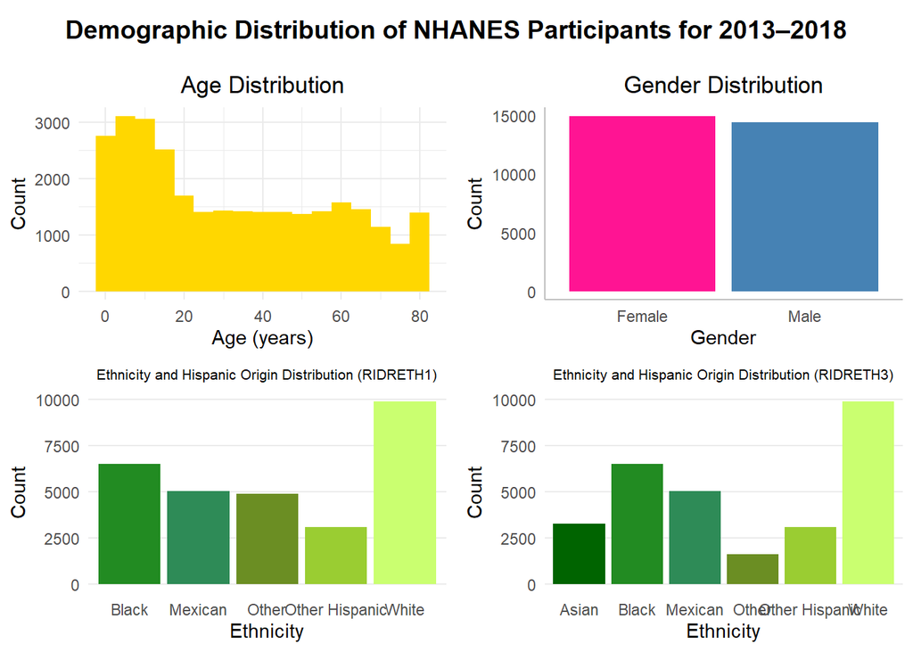

```r
# Age variable
age_plot <- ggplot(nhanes_data, aes(x = age)) +
  geom_histogram(binwidth = 5, fill = "gold") +
  labs(
    title = "Age Distribution",
    x     = "Age (years)",
    y     = "Count"
  ) +
  theme_minimal()+
  theme(
    plot.title = element_text(hjust = 0.5)
  )

# Gender Variable
gender_plot <- ggplot(nhanes_data, aes(x = gender, fill = gender)) +
  geom_bar() +
  scale_fill_manual(
    values = c(
      "Male"   = "steelblue",
      "Female" = "deeppink"
    )
  ) +
  labs(
    title = "Gender Distribution",
    x     = "Gender",
    y     = "Count"
  ) +
  theme_minimal() +
  theme(
    plot.title = element_text(hjust = 0.5),
    legend.position = "none",
    panel.grid = element_blank(),
    axis.line = element_line(color = "grey75")
  )

# Ethnicity Variables
# Define the same colors for both ethnicity variables
ethnicity_colors <- c(
  "Mexican" = "seagreen",
  "Other Hispanic" = "yellowgreen",
  "White" = "darkolivegreen1",
  "Black" = "forestgreen",
  "Asian" = "darkgreen",
  "Other" = "olivedrab"
)

# Ethnicity 1
ethnicity1_plot <- ggplot(nhanes_data,
  aes(x = ethnicity_1, fill = ethnicity_1)
  ) +
  geom_bar() +
  scale_fill_manual(values = ethnicity_colors) +
  labs(
    title = "Ethnicity and Hispanic Origin Distribution (RIDRETH1)",
    x     = "Ethnicity",
    y     = "Count"
  ) +
theme_minimal() +
  theme(
    plot.title         = element_text(hjust = 0.5, size = 8),
    legend.position    = "none",
    panel.grid.major.x = element_blank(),
    panel.grid.minor.x = element_blank(),
    panel.grid.minor.y = element_blank()
  )

# Ethnicity 2
ethnicity2_plot <- ggplot(nhanes_data,
  aes(x = ethnicity_2, fill = ethnicity_2)
  ) +
  geom_bar() +
  scale_fill_manual(values = ethnicity_colors) +
  labs(
    title = "Ethnicity and Hispanic Origin Distribution (RIDRETH3)",
    x     = "Ethnicity",
    y     = "Count"
  ) +
  theme_minimal() +
  theme(
    plot.title         = element_text(hjust = 0.5, size = 8),
    legend.position    = "none",
    panel.grid.major.x = element_blank(),
    panel.grid.minor.x = element_blank(),
    panel.grid.minor.y = element_blank()
  )

# Combining plots
demographic_distribution <- plot_grid(
  age_plot,
  gender_plot,
  ethnicity1_plot,
  ethnicity2_plot,
  ncol = 2
)
# Adding an overall title
demographic_distribution_final <- ggdraw() +
  draw_plot(demographic_distribution, y = 0, height = 0.90) +
  draw_label(
    "Demographic Distribution of NHANES Participants for 2013–2018",
    x = 0.5,
    y = 0.97,
    hjust = 0.5,
    vjust = 1,
    fontface = "bold"
  )

demographic_distribution_final
```

```r
# Removing the ethnicity 1 variable
nhanes_data <- nhanes_data %>%
  select(-ethnicity_1)
```

# 3. Improving a Ggplot Figure

The original figure has several points that could be improved. First, the use of a rainbow color palette makes it difficult to distinguish between some individuals, such as participants 7 and 8 or 18 and 19. To make the effect of the diet on each participant’s weight more apparent, the colors could instead be used to distinguish between participants who lost, gained, or maintained their weight, rather than assigning a different color to each individual. I would accomplish this by creating a new variable in the dataset that groups each participant into one of these three categories. This would make the weight changes easier to interpret while reducing the number of colors in the figure. The background also makes the figure feel somewhat crowded and does not add much information. I would therefore use simple horizontal gridlines to make changes in patients’ weight easier to follow. Finally, since weight could be reported in either kilograms or pounds, I would include the unit of measurement in the axis title to avoid confusion and add a figure title for a cleaner result.

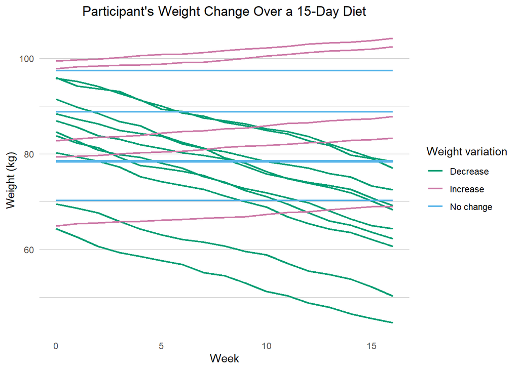

```r
# Separating the patients in three categories according to their weight variation
weight_change <- diet_data %>%
  group_by(Participant) %>%
  summarise(
    initial_weight = first(Weight),
    final_weight = last(Weight)
  ) %>%
  mutate(
    weight_variation = case_when(
      final_weight < initial_weight ~ "Decrease",
      final_weight > initial_weight ~ "Increase",
      TRUE ~ "No change"
    )
  )

# Adding the weight variation variable to the original data
diet_data <- diet_data %>%
  left_join(
    weight_change %>% select(Participant, weight_variation),
    by = "Participant"
  )
# Creating the improved plot
ggplot(diet_data, aes(x = Week, y = Weight, group = Participant, color = weight_variation)) +
  geom_line(linewidth = 0.8) +
  scale_color_manual(
    values = c(
      "Increase"  = "#CC79A7",
      "No change" = "#56B4E9",
      "Decrease"  = "#009E73"
    )) +
  labs(
    title = "Participant's Weight Change Over a 15-Day Diet",
    x     = "Week",
    y     = "Weight (kg)",
    color = "Weight variation"
  ) +
  theme_minimal() +
  theme(
    plot.title         = element_text(hjust = 0.5),
    panel.grid.major.x = element_blank(),
    panel.grid.minor.x = element_blank(),
    panel.grid.major.y = element_line(color = "grey", linewidth = 0.2),
    panel.grid.minor.y = element_line(color = "grey", linewidth = 0.2)
    )
```

# 4. Exploring Relationships through Visualizations

## Introduction

The National Health and Nutrition Examination Survey (NHANES), conducted by the U.S. Centers for Disease Control and Prevention’s (CDC’s) National Center for Health Statistics (NCHS), is a national survey that collects data on the health of American adults and children (National Center for Health Statistics [NCHS], 2024). Between 2013 and 2018, the survey collected health data from a diverse demographic, including measurements of blood pressure (NCHS, 2024). These data allow for the examination of patterns in systolic blood pressure (SBP), including its increase with age.